# Introduction to Statistics in R

Susan Johnston

28 November 2017

## Introduction

This is an **R Markdown** script for the practical *Introduction to Statistics in R*. In the script, we will cover:

- How to use R Markdown
- How to carry out the following statistical tests:
  - Chi-squared test;
  - Two sample t-test;
  - Linear regression.

Code can be embedded in the document:

```r
head(iris)
```

```
##   Sepal.Length Sepal.Width Petal.Length Petal.Width Species
## 1          5.1         3.5          1.4         0.2  setosa
## 2          4.9         3.0          1.4         0.2  setosa
## 3          4.7         3.2          1.3         0.2  setosa
## 4          4.6         3.1          1.5         0.2  setosa
## 5          5.0         3.6          1.4         0.2  setosa
## 6          5.4         3.9          1.7         0.4  setosa
```

Or code can be run inline e.g. Two plus two equals 4.

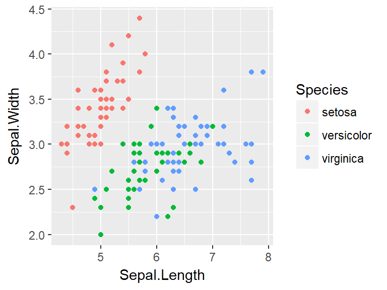

## Chi-squared test

Here we examine the differences in the frequency of red and black ladybirds (*Adalia bipunctata*) in rural and industrial habitats. Our question is: are dark morphs more likely to reside in dark (industrial) backgrounds? The null hypothesis is that there is no association between ladybird colour morph and habitat type.

Ladybird colour morphs were not equally distributed in the two habitats (Chi-Squared = 19.1028921, df = 1, P = 1.238570610^{-5}), with black morphs occurring more frequently in industrial habitats and red morphs more frequently in rural habitats (Figure 1).

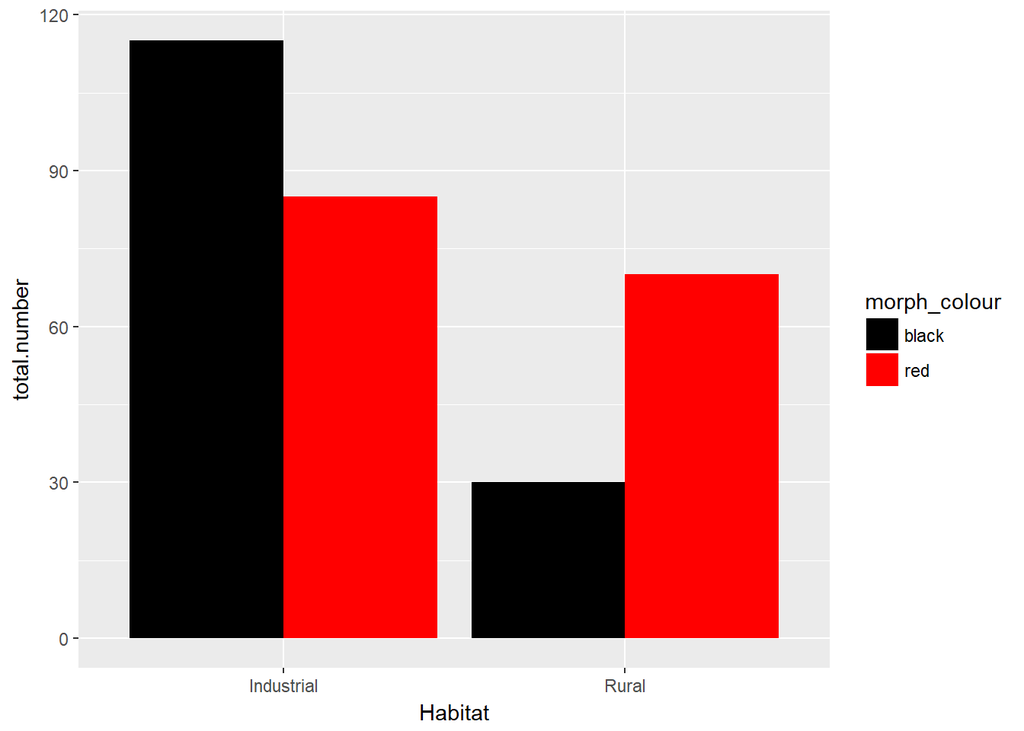

## Two-sample t-test

Here, we will use data from two *Iris* species, *I. virginica* and *I. versicolor* to determine if their sepal lengths are significantly different (Figure 2). The null hypothesis is that there is no significant different between the means in each species.

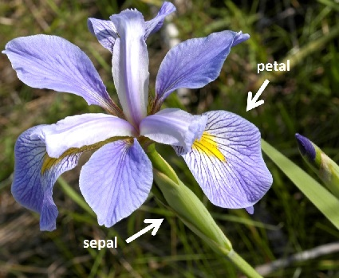

First, we will visualise the data with a boxplot and a histogram:

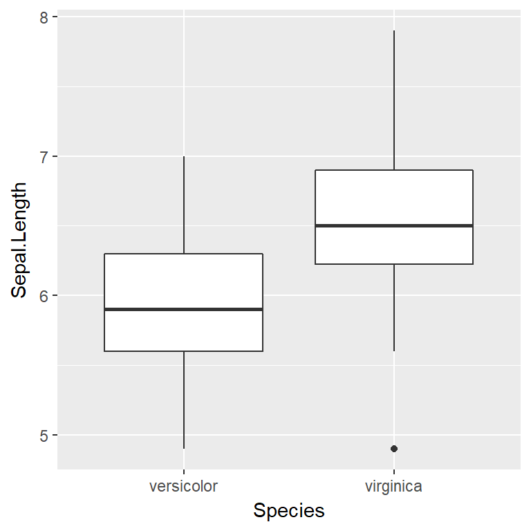

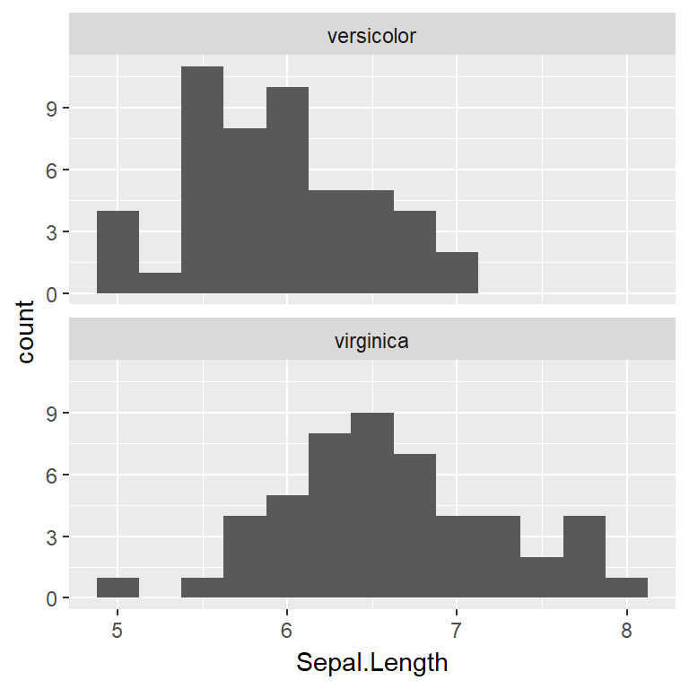

Sepal lengths in *Iris virginica* were significantly higher than in *I.versicolor* (Welch two sample t-test, t = -5.6291653, df = 94.0254863, P = 1.866144410^{-7}).

## Linear Regression

Here, we use Francis Galton’s human height dataset from 1886 to determine if daughter ault height varies relative to the mean height of her parents. Our null hypothesis is that mid-parental height is not correlated with daughter adult height.

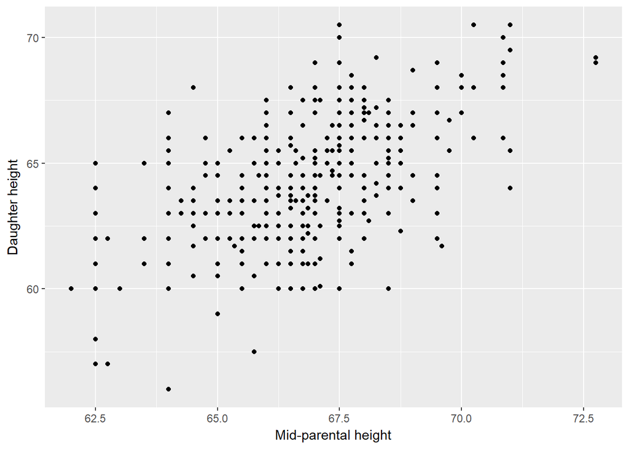

We will examine this relationship using a linear regression.

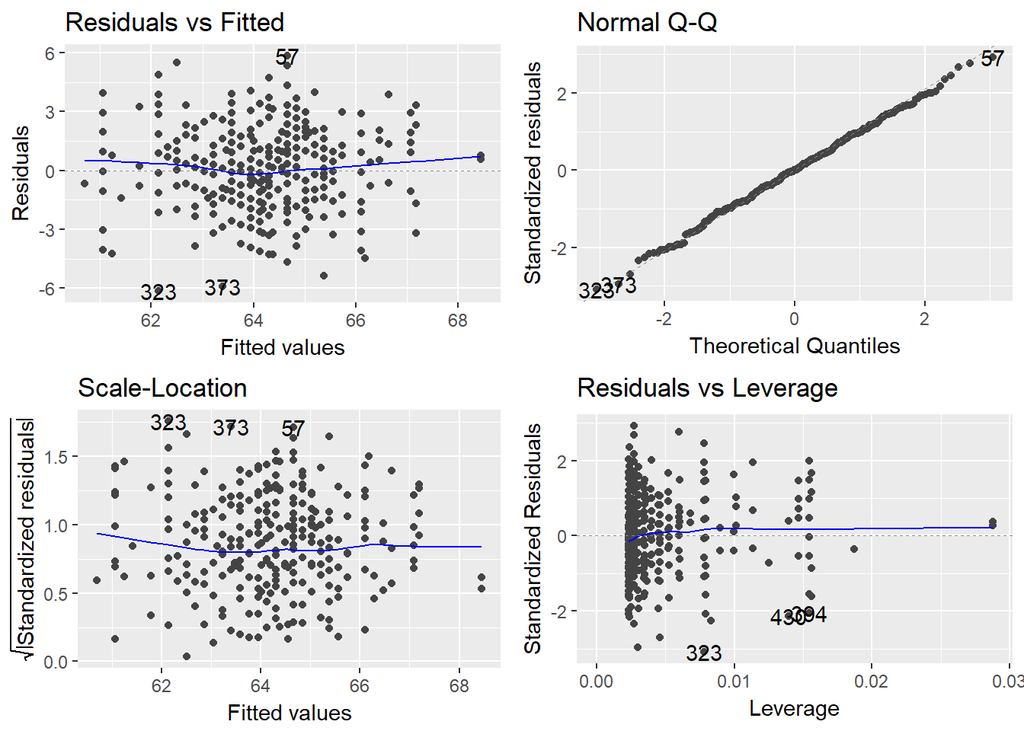

```r
lm.heights <- lm(height ~ mid.parent, data = heights)
autoplot(lm.heights)
```

```r
lm.heights
```

```
##
## Call:
## lm(formula = height ~ mid.parent, data = heights)
##
## Coefficients:
## (Intercept)   mid.parent
##     15.9671       0.7214
```

```r
summary(lm.heights)
```

```
##
## Call:
## lm(formula = height ~ mid.parent, data = heights)
##
## Residuals:
##     Min      1Q  Median      3Q     Max
## -6.1365 -1.3989  0.0028  1.4207  5.8386
##
## Coefficients:
##             Estimate Std. Error t value Pr(>|t|)
## (Intercept) 15.96711    3.60237   4.432 1.18e-05 ***
## mid.parent   0.72140    0.05396  13.369  < 2e-16 ***
## ---
## Signif. codes:  0 '***' 0.001 '**' 0.01 '*' 0.05 '.' 0.1 ' ' 1
##
## Residual standard error: 1.995 on 431 degrees of freedom
## Multiple R-squared:  0.2931, Adjusted R-squared:  0.2915
## F-statistic: 178.7 on 1 and 431 DF,  p-value: < 2.2e-16
```

The regression line is fit on the plot:

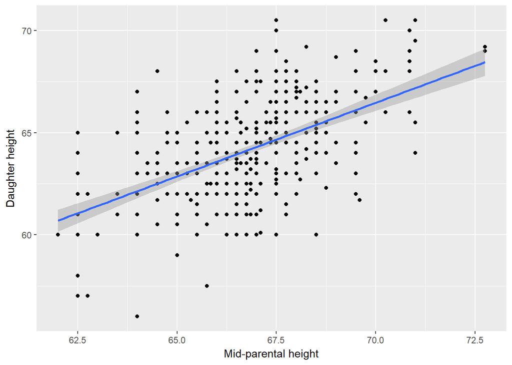

In the Galton dataset, for each unit increase in mid-parental height, there is an increase in daughter height by 0.72 inches (slope = 0.7213964, t = 13.3689941, df = 431, P = 2.40569210^{-34})